# Tuning Fit and Compile Arguments

## Introduction

While `kerasnip` makes it easy to tune the architecture of a Keras model (e.g., the number of layers or the number of units in a layer), it is often just as important to tune the parameters that control the training process itself. `kerasnip` exposes these parameters through special `fit_*` and `compile_*` arguments in the model specification.

This vignette provides a comprehensive example of how to tune these arguments within a `tidymodels` workflow. We will tune:

- **`fit_epochs`**: The number of training epochs.
- **`fit_batch_size`**: The number of samples per gradient update.
- **`compile_optimizer`**: The optimization algorithm (e.g., “adam”, “sgd”).
- **`compile_loss`**: The loss function used for training.
- **`learn_rate`**: The learning rate for the optimizer.

Fit arguments can be written either with the `fit_` prefix (`fit_epochs`) or without it (`epochs`), matching the names used by other tidymodels neural-network engines. When both are supplied, the `fit_` version takes precedence.

## Setup

First, we load the necessary packages.

```r
library(kerasnip)
library(tidymodels)
library(keras3)
```

## Data Preparation

We will use the classic `iris` dataset for this example. It’s a simple, small dataset, which is ideal for demonstrating the tuning process without long training times.

```r
# Split data into training and testing sets
set.seed(123)
iris_split <- initial_split(iris, prop = 0.8, strata = Species)
iris_train <- training(iris_split)
iris_test <- testing(iris_split)

# Create cross-validation folds for tuning
iris_folds <- vfold_cv(iris_train, v = 3, strata = Species)
```

## Define a `kerasnip` Model

We’ll create a very simple sequential model with a single dense layer. This keeps the focus on tuning the `fit_*` and `compile_*` arguments rather than the model architecture.

```r
# Define layer blocks
input_block <- function(model, input_shape) {
  keras_model_sequential(input_shape = input_shape)
}
dense_block <- function(model, units = 10) {
  model |> layer_dense(units = units, activation = "relu")
}
output_block <- function(model, num_classes) {
  model |> layer_dense(units = num_classes, activation = "softmax")
}

# Create the kerasnip model specification function
create_keras_sequential_spec(
  model_name = "iris_mlp",
  layer_blocks = list(
    input = input_block,
    dense = dense_block,
    output = output_block
  ),
  mode = "classification"
)
```

## Define the Tunable Specification

Now, we create an instance of our `iris_mlp` model. We set the arguments we want to optimize to `tune()`.

```r
# Define the tunable model specification
tune_spec <- iris_mlp(
  dense_units = 16, # Keep architecture fixed for this example
  fit_epochs = tune(),
  fit_batch_size = tune(),
  compile_optimizer = tune(),
  compile_loss = tune(),
  learn_rate = tune()
) |>
  set_engine("keras")

print(tune_spec)
```

```
#> iris mlp Model Specification (classification)
#>
#> Main Arguments:
#>   num_input = structure(list(), class = "rlang_zap")
#>   num_dense = structure(list(), class = "rlang_zap")
#>   num_output = structure(list(), class = "rlang_zap")
#>   dense_units = 16
#>   learn_rate = tune()
#>   fit_batch_size = tune()
#>   fit_epochs = tune()
#>   fit_callbacks = structure(list(), class = "rlang_zap")
#>   fit_validation_split = structure(list(), class = "rlang_zap")
#>   fit_validation_data = structure(list(), class = "rlang_zap")
#>   fit_shuffle = structure(list(), class = "rlang_zap")
#>   fit_class_weight = structure(list(), class = "rlang_zap")
#>   fit_sample_weight = structure(list(), class = "rlang_zap")
#>   fit_initial_epoch = structure(list(), class = "rlang_zap")
#>   fit_steps_per_epoch = structure(list(), class = "rlang_zap")
#>   fit_validation_steps = structure(list(), class = "rlang_zap")
#>   fit_validation_batch_size = structure(list(), class = "rlang_zap")
#>   fit_validation_freq = structure(list(), class = "rlang_zap")
#>   fit_verbose = structure(list(), class = "rlang_zap")
#>   fit_view_metrics = structure(list(), class = "rlang_zap")
#>   compile_optimizer = tune()
#>   compile_loss = tune()
#>   compile_metrics = structure(list(), class = "rlang_zap")
#>   compile_loss_weights = structure(list(), class = "rlang_zap")
#>   compile_weighted_metrics = structure(list(), class = "rlang_zap")
#>   compile_run_eagerly = structure(list(), class = "rlang_zap")
#>   compile_steps_per_execution = structure(list(), class = "rlang_zap")
#>   compile_jit_compile = structure(list(), class = "rlang_zap")
#>   compile_auto_scale_loss = structure(list(), class = "rlang_zap")
#>
#> Computational engine: keras
```

## Create Workflow and Tuning Grid

Next, we create a `workflow` and define the search space for our hyperparameters using `dials`. `kerasnip` provides special `dials` parameter functions for `optimizer` and `loss`.

```r
# Create a simple recipe
iris_recipe <- recipe(Species ~ ., data = iris_train) |>
  step_normalize(all_numeric_predictors())

# Create the workflow
tune_wf <- workflow() |>
  add_recipe(iris_recipe) |>
  add_model(tune_spec)

# Define the tuning grid
params <- extract_parameter_set_dials(tune_wf) |>
  update(
    fit_epochs = epochs(c(10, 30)),
    fit_batch_size = batch_size(c(16, 64), trans = NULL),
    compile_optimizer = optimizer_function(values = c("adam", "sgd", "rmsprop")),
    compile_loss = loss_function_keras(values = c("categorical_crossentropy", "kl_divergence")),
    learn_rate = learn_rate(c(0.001, 0.01), trans = NULL)
  )

set.seed(456)
tuning_grid <- grid_regular(params, levels = 2)

tuning_grid
```

```
#> # A tibble: 32 × 5
#>    learn_rate fit_batch_size fit_epochs compile_optimizer compile_loss
#>         <dbl>          <int>      <int> <chr>             <chr>
#>  1      0.001             16         10 adam              categorical_crossentropy
#>  2      0.01              16         10 adam              categorical_crossentropy
#>  3      0.001             64         10 adam              categorical_crossentropy
#>  4      0.01              64         10 adam              categorical_crossentropy
#>  5      0.001             16         30 adam              categorical_crossentropy
#>  6      0.01              16         30 adam              categorical_crossentropy
#>  7      0.001             64         30 adam              categorical_crossentropy
#>  8      0.01              64         30 adam              categorical_crossentropy
#>  9      0.001             16         10 sgd               categorical_crossentropy
#> 10      0.01              16         10 sgd               categorical_crossentropy
#> # ℹ 22 more rows
```

## Tune the Model

With the workflow and grid defined, we can now run the hyperparameter tuning using `tune_grid()`.

```r
tune_res <- tune_grid(
  tune_wf,
  resamples = iris_folds,
  grid = tuning_grid,
  metrics = metric_set(accuracy, roc_auc),
  control = control_grid(save_pred = FALSE, save_workflow = TRUE, verbose = FALSE)
)
```

[output not shown]

[output cut: 233 more lines]

[output not shown]

## Inspect the Results

Let’s examine the results to see how the different combinations of fitting and compilation parameters performed.

```r
# Show the best performing models based on accuracy
show_best(tune_res, metric = "accuracy")
```

```
#> # A tibble: 5 × 11
#>   learn_rate fit_batch_size fit_epochs compile_optimizer compile_loss     .metric .estimator  mean     n std_err .config
#>        <dbl>          <int>      <int> <chr>             <chr>            <chr>   <chr>      <dbl> <int>   <dbl> <chr>
#> 1       0.01             16         30 adam              categorical_cro… accura… multiclass 0.951     3 0.0132  pre0_m…
#> 2       0.01             16         30 adam              kl_divergence    accura… multiclass 0.951     3 0.0132  pre0_m…
#> 3       0.01             64         30 adam              categorical_cro… accura… multiclass 0.942     3 0.00672 pre0_m…
#> 4       0.01             64         30 adam              kl_divergence    accura… multiclass 0.918     3 0.0305  pre0_m…
#> 5       0.01             16         10 adam              kl_divergence    accura… multiclass 0.901     3 0.0220  pre0_m…
```

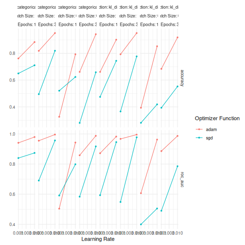

```r
# Plot the results
autoplot(tune_res) + theme_minimal()
```

```r
# Select the best hyperparameters
best_params <- select_best(tune_res, metric = "accuracy")
print(best_params)
```

```
#> # A tibble: 1 × 6
#>   learn_rate fit_batch_size fit_epochs compile_optimizer compile_loss             .config
#>        <dbl>          <int>      <int> <chr>             <chr>                    <chr>
#> 1       0.01             16         30 adam              categorical_crossentropy pre0_mod21_post0
```

The results show that `tune` has successfully explored different optimizers, loss functions, learning rates, epochs, and batch sizes, identifying the combination that yields the best accuracy.

## Finalize and Fit

Finally, we finalize our workflow with the best-performing hyperparameters and fit the model one last time on the full training dataset.

```r
# Finalize the workflow
final_wf <- finalize_workflow(tune_wf, best_params)

# Fit the final model
final_fit <- fit(final_wf, data = iris_train)
```

```
#> 4/4 - 0s - 27ms/step
```

```r
print(final_fit)
```

[output not shown]

[output cut: 8 more lines]

[output not shown]

We can now use this `final_fit` object to make predictions on the test set.

```r
# Make predictions
predictions <- predict(final_fit, new_data = iris_test)
```

```
#> 1/1 - 0s - 57ms/step
```

```r
# Evaluate performance
bind_cols(predictions, iris_test) |>
  accuracy(truth = Species, estimate = .pred_class)
```

```
#> # A tibble: 1 × 3
#>   .metric  .estimator .estimate
#>   <chr>    <chr>          <dbl>
#> 1 accuracy multiclass     0.967
```

## Conclusion

This vignette demonstrated how to tune the crucial `fit_*` and `compile_*` arguments of a Keras model within the `tidymodels` framework using `kerasnip`. By exposing these as tunable parameters, `kerasnip` gives you full control over the training process, allowing you to optimize not just the model’s architecture, but also how it learns.